# longer-term

Yunfeng Yang

3/7/2022

# Data preprocessing

```r
bending <- read.csv("bending-pl.csv", header = T)
# convert psi to Mpa
#  1 thousand psi = 6.895 MPa
bending[,1] <- bending[,1]/1000*6.895
l <- 4500/1000*6.895
# bending_mar <- bending[1:195,]
# bending_dmg <- bending[195:341,]

R100_data <- bending[bending[,2] == "R100",1]
R20_data <- bending[bending[,2] == "R20",1]
R20R100_data <- bending[bending[,2] == "R20R100",1]


length(R100_data)
```

```
## [1] 138
```

```r
length(R20_data)
```

```
## [1] 57
```

```r
length(R20R100_data)
```

```
## [1] 146
```

# Data simulation

We let thresh ($l$) = 0.75 and $\alpha = 0.5$.

```r
# mu = 47.91, sd = 18.84
R100_data <- rnorm(138, mean = 47.91, sd =  18.84)
l <- qnorm(.2, mean =  47.91, sd = 18.84)

thresh <- 0.75
alpha <- .5

samples <- rnorm(500, mean = 47.91, sd =  18.84)

R20_data <- samples[which(samples < l)]
R20R100_data <- samples[which(samples > l)]
for (ii in 1: length(R20R100_data)){
  if(l > thresh*R20R100_data[ii]){
    R20R100_data[ii] <- alpha * R20R100_data[ii]
  }
}


sum(l > thresh*R20R100_data)
```

```
## [1] 96
```

# Use MLE

- Recall that in the overleaf file (likelihood derivation), the pdf of the third term is 0. In the log likelihood, it is assigned with -10000 to represent `-Inf`. Check the third the condition of the `dmglik` function.
- Also, mu and sigma are fixed as the true value, i.e., only alpha is estimated.
- The y axis is negative likelihood, which should be minimized. We see that $alpha = 0.5$ minimized the negative likelihood.

```r
dmglik <- function(theta){
  # mu <- theta[1]
  # sigma <- theta[2]
  mu <- 47.91
  sigma <- 18.84
  alpha <- theta
  lik <- 0
  for (jj in 1:length(R20R100_data)){
    if(R20R100_data[jj]/alpha < l/thresh){
      lik <- lik - log(alpha) + dnorm(R20R100_data[jj]/alpha, mean =  mu,sd = sigma, log = TRUE)
    }else if(R20R100_data[jj]/alpha > l/thresh && R20R100_data[jj] > l/thresh){
      lik <- lik + dnorm(R20R100_data[jj], mean = mu, sd = sigma,log = TRUE)
    }
    else if(R20R100_data[jj]/alpha > l/thresh && R20R100_data[jj] < l/thresh){
      lik <- lik-10000
    }
  }
  # lik <-  lik + sum(dnorm(c(R100_data,R20_data), mean = mu, sd = sigma, log = TRUE))
  return(-1*lik)
}

optimdmg <- optimize(dmglik, c(0,20))
optimdmg$minimum
```

```
## [1] 0.4954578
```

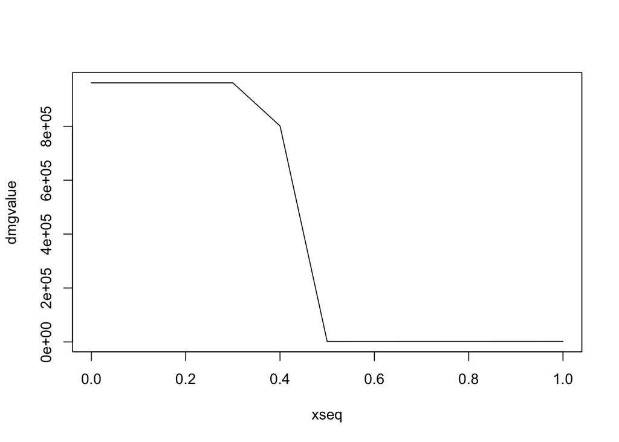

```r
# show alpha from 0 to 1
dmgvalue <- c()
xseq <- seq(from = 0, to = 1, by= 0.1)
for (jj in 1:length(xseq)){
  dmgvalue[jj] <- dmglik(xseq[jj])
}

plot(xseq, dmgvalue,type = 'l')
```

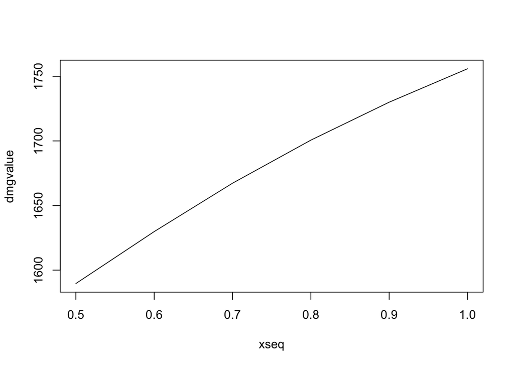

```r
# show alpha from 0.5 to 1
dmgvalue <- c()
xseq <- seq(from = 0.5, to = 1, by= 0.1)
for (jj in 1:length(xseq)){
  dmgvalue[jj] <- dmglik(xseq[jj])
}

plot(xseq, dmgvalue,type = 'l')
```

- In fact, $\alpha < 0.5$ should provide `Inf`.
- So the true alpha is always at the left boundary, i.e., the lowest alpha which can provide a valid likelihood.
- It is the same result when $\alpha = 0.8$ or $0.1$.

# Stan fit

```r
library(rstan)
standata <- list(N_R20 = length(R20_data),N_R100 = length(R100_data),N_R20R100 = length(R20R100_data),
                 X_R20 = R20_data, X_R100 = R100_data, X_R20R100 = R20R100_data,
                 l = l, thresh = .75)
init_dmg <- function() {
  list(mu = 45, sigma = 20, alpha =0.5)
}
options(mc.cores = parallel::detectCores())
dmg_mod <- stan_model("longerterm.stan")
```

[output not shown]

```r
dmgfit <- rstan::sampling(dmg_mod, data = standata, init = init_dmg, iter = 4000)

print(dmgfit)
```

```
## Inference for Stan model: longerterm.
## 4 chains, each with iter=4000; warmup=2000; thin=1;
## post-warmup draws per chain=2000, total post-warmup draws=8000.
##
##           mean se_mean   sd     2.5%      25%      50%      75%    97.5% n_eff
## mu       47.80    0.03 0.74    46.32    47.31    47.82    48.32    49.20   732
## sigma    19.12    0.02 0.52    18.15    18.76    19.10    19.45    20.20   644
## alpha     0.50    0.00 0.00     0.50     0.50     0.50     0.50     0.50   605
## lp__  -2719.70    0.05 1.40 -2723.29 -2720.34 -2719.38 -2718.69 -2717.97   799
##       Rhat
## mu    1.01
## sigma 1.00
## alpha 1.01
## lp__  1.01
##
## Samples were drawn using NUTS(diag_e) at Tue Apr  5 21:35:03 2022.
## For each parameter, n_eff is a crude measure of effective sample size,
## and Rhat is the potential scale reduction factor on split chains (at
## convergence, Rhat=1).
```

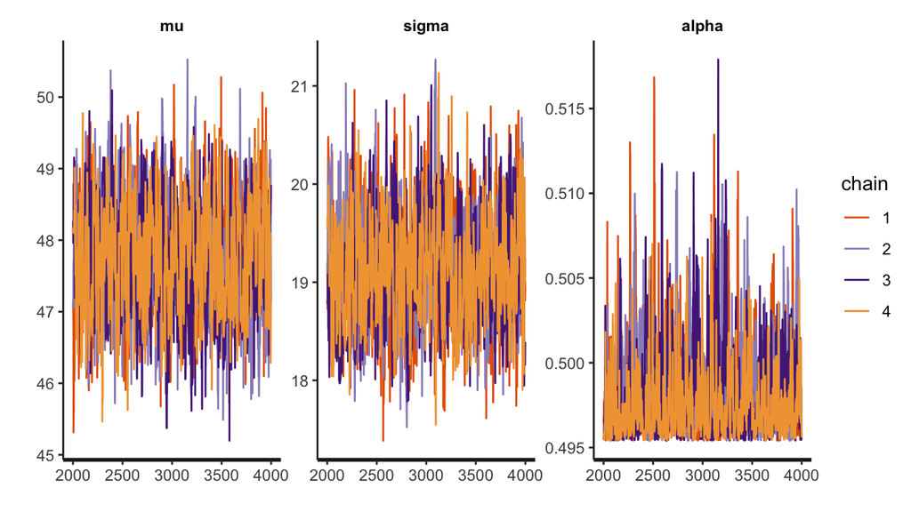

```r
traceplot(dmgfit)
```

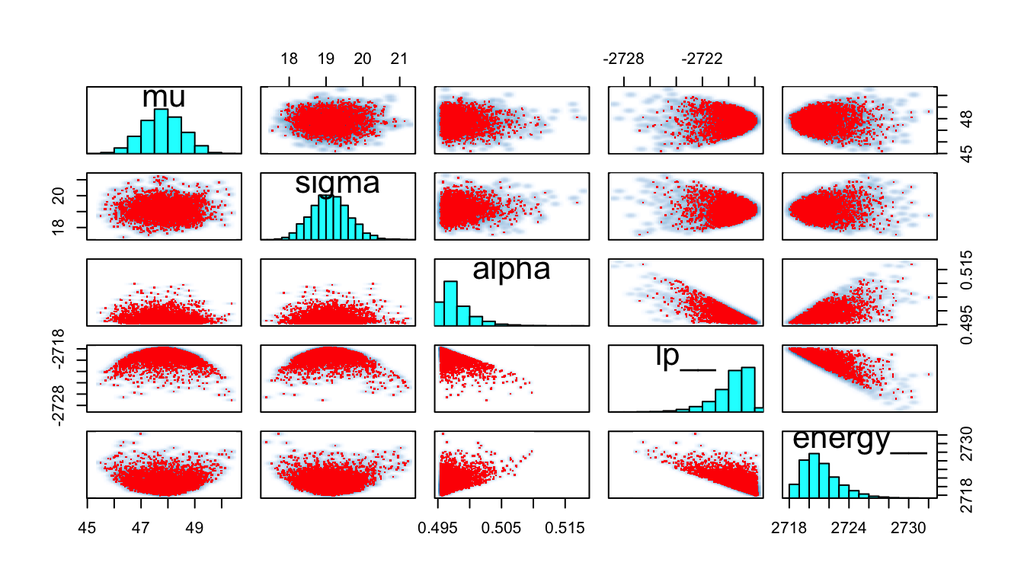

```r
pairs(dmgfit)
```

- alpha is pretty right-skewed as we know that alpha should be larger than 0.5
- Not sure whether it is a good estimation but it makes sense

# Real data analysis

I tried several thresh values. They basically provide very similar `lp__`. Here I use thresh = 0.82, which is slightly better.

```r
bending <- read.csv("bending-pl.csv", header = T)
# convert psi to Mpa
#  1 thousand psi = 6.895 MPa
bending[,1] <- bending[,1]/1000*6.895
l <- 4500/1000*6.895
# bending_mar <- bending[1:195,]
# bending_dmg <- bending[195:341,]

R100_data <- bending[bending[,2] == "R100",1]
R20_data <- bending[bending[,2] == "R20",1]
R20R100_data <- bending[bending[,2] == "R20R100",1]




##--------------stan fitting----------------
standata <- list(N_R20 = length(R20_data),N_R100 = length(R100_data),N_R20R100 = length(R20R100_data),
                 X_R20 = R20_data, X_R100 = R100_data, X_R20R100 = R20R100_data,
                 l = l, thresh = 0.82)
init_dmg <- function() {
  list(mu = 45, sigma = 20, alpha =0.5)
}
options(mc.cores = parallel::detectCores())
# dmg_mod <- stan_model("longerterm.stan")
dmgfit <- rstan::sampling(dmg_mod, data = standata, init = init_dmg)

print(dmgfit)
```

```
## Inference for Stan model: longerterm.
## 4 chains, each with iter=2000; warmup=1000; thin=1;
## post-warmup draws per chain=1000, total post-warmup draws=4000.
##
##           mean se_mean   sd     2.5%      25%      50%      75%    97.5% n_eff
## mu       49.73    0.04 1.07    47.64    49.02    49.71    50.44    51.77   857
## sigma    20.14    0.03 0.82    18.62    19.56    20.10    20.68    21.79   855
## alpha     1.04    0.00 0.04     0.99     1.01     1.03     1.06     1.11   549
## lp__  -1504.86    0.04 1.23 -1508.09 -1505.36 -1504.55 -1504.01 -1503.44   914
##       Rhat
## mu    1.00
## sigma 1.00
## alpha 1.01
## lp__  1.00
##
## Samples were drawn using NUTS(diag_e) at Tue Apr  5 21:35:15 2022.
## For each parameter, n_eff is a crude measure of effective sample size,
## and Rhat is the potential scale reduction factor on split chains (at
## convergence, Rhat=1).
```

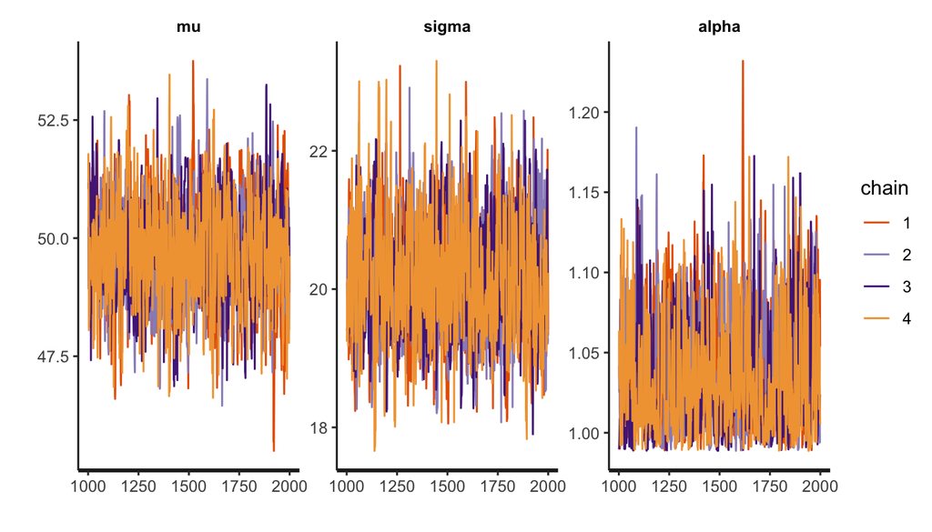

```r
traceplot(dmgfit)
```

```r
##--------------stan fitting----------------
standata <- list(N_R20 = length(R20_data),N_R100 = length(R100_data),N_R20R100 = length(R20R100_data),
                 X_R20 = R20_data, X_R100 = R100_data, X_R20R100 = R20R100_data,
                 l = l, thresh = 0.89)
init_dmg <- function() {
  list(mu = 45, sigma = 20, alpha =0.5)
}
options(mc.cores = parallel::detectCores())
# dmg_mod <- stan_model("longerterm.stan")
dmgfit <- rstan::sampling(dmg_mod, data = standata, init = init_dmg)

print(dmgfit)
```

```
## Inference for Stan model: longerterm.
## 4 chains, each with iter=2000; warmup=1000; thin=1;
## post-warmup draws per chain=1000, total post-warmup draws=4000.
##
##           mean se_mean   sd     2.5%      25%      50%      75%    97.5% n_eff
## mu       49.67    0.04 1.11    47.46    48.93    49.69    50.39    51.84   919
## sigma    20.18    0.02 0.81    18.73    19.62    20.13    20.69    21.86  1251
## alpha     0.56    0.01 0.31     0.04     0.28     0.55     0.83     1.08   760
## lp__  -1505.30    0.05 1.37 -1508.74 -1506.00 -1505.02 -1504.30 -1503.56   895
##       Rhat
## mu       1
## sigma    1
## alpha    1
## lp__     1
##
## Samples were drawn using NUTS(diag_e) at Tue Apr  5 21:35:18 2022.
## For each parameter, n_eff is a crude measure of effective sample size,
## and Rhat is the potential scale reduction factor on split chains (at
## convergence, Rhat=1).
```

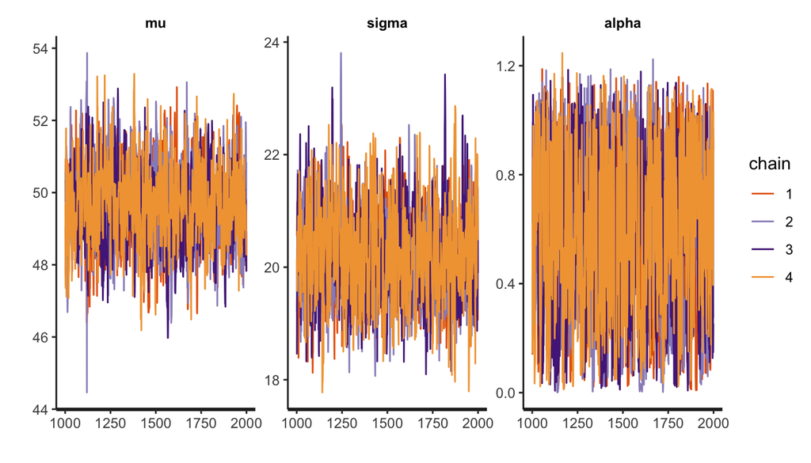

```r
traceplot(dmgfit)
```

# likelihood plot

Based on this plot , we can tell that the threshold <= 0.84 and threshold >= 0.85 can give totally different likelihood plot.

Also, based on likelihood value, all the pieces are possible. If it has impossible pieces, the likelihood is very low.

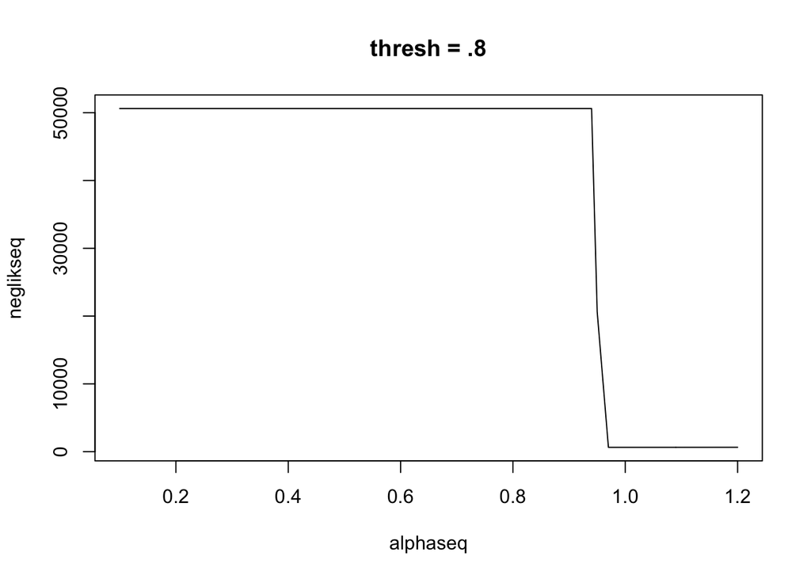

```r
thresh <-  .8
neglik <- function(theta){
  # mu <- theta[1]
  # sigma <- theta[2]
  mu <- 47.91
  sigma <- 18.84
  alpha <- theta
  lik <- 0
  for (jj in 1:length(R20R100_data)){
    if(R20R100_data[jj]/alpha < l/thresh){
      lik <- lik - log(alpha) + dnorm(R20R100_data[jj]/alpha, mean =  mu,sd = sigma, log = TRUE)
    }else if(R20R100_data[jj]/alpha > l/thresh && R20R100_data[jj] > l/thresh){
      lik <- lik + dnorm(R20R100_data[jj], mean = mu, sd = sigma,log = TRUE)
    }
    else if(R20R100_data[jj]/alpha > l/thresh && R20R100_data[jj] < l/thresh){
      lik <- lik-10000
    }
  }
  # lik <-  lik + sum(dnorm(c(R100_data,R20_data), mean = mu, sd = sigma, log = TRUE))
  return(-1*lik)
}



alphaseq <- seq(from = 0.1,to = 1.2, by = 0.01)
neglikseq <- c()
for (iseq in 1:length(alphaseq) ){
  neglikseq[iseq] <- neglik(alphaseq[iseq])

}

plot(alphaseq,neglikseq,type = 'l',main = 'thresh = .8')
```

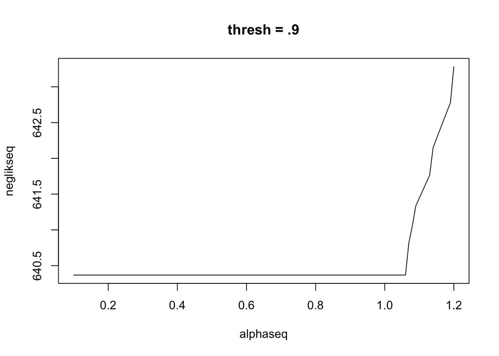

```r
thresh <-  .9
neglik <- function(theta){
  # mu <- theta[1]
  # sigma <- theta[2]
  mu <- 47.91
  sigma <- 18.84
  alpha <- theta
  lik <- 0
  for (jj in 1:length(R20R100_data)){
    if(R20R100_data[jj]/alpha < l/thresh){
      lik <- lik - log(alpha) + dnorm(R20R100_data[jj]/alpha, mean =  mu,sd = sigma, log = TRUE)
    }else if(R20R100_data[jj]/alpha > l/thresh && R20R100_data[jj] > l/thresh){
      lik <- lik + dnorm(R20R100_data[jj], mean = mu, sd = sigma,log = TRUE)
    }
    else if(R20R100_data[jj]/alpha > l/thresh && R20R100_data[jj] < l/thresh){
      lik <- lik-10000
    }
  }
  # lik <-  lik + sum(dnorm(c(R100_data,R20_data), mean = mu, sd = sigma, log = TRUE))
  return(-1*lik)
}



alphaseq <- seq(from = 0.1,to = 1.2, by = 0.01)
neglikseq <- c()
for (iseq in 1:length(alphaseq) ){
  neglikseq[iseq] <- neglik(alphaseq[iseq])

}

plot(alphaseq,neglikseq,type = 'l',main = 'thresh = .9')
```

When we look at the second condition of the lilkehood ‘else if(R20R100_data[jj]/alpha > l/thresh && R20R100_data[jj] > l/thresh)’

```r
R20R100_data/alpha > l/thresh
```

```
##   [1] TRUE TRUE TRUE TRUE TRUE TRUE TRUE TRUE TRUE TRUE TRUE TRUE TRUE TRUE TRUE
##  [16] TRUE TRUE TRUE TRUE TRUE TRUE TRUE TRUE TRUE TRUE TRUE TRUE TRUE TRUE TRUE
##  [31] TRUE TRUE TRUE TRUE TRUE TRUE TRUE TRUE TRUE TRUE TRUE TRUE TRUE TRUE TRUE
##  [46] TRUE TRUE TRUE TRUE TRUE TRUE TRUE TRUE TRUE TRUE TRUE TRUE TRUE TRUE TRUE
##  [61] TRUE TRUE TRUE TRUE TRUE TRUE TRUE TRUE TRUE TRUE TRUE TRUE TRUE TRUE TRUE
##  [76] TRUE TRUE TRUE TRUE TRUE TRUE TRUE TRUE TRUE TRUE TRUE TRUE TRUE TRUE TRUE
##  [91] TRUE TRUE TRUE TRUE TRUE TRUE TRUE TRUE TRUE TRUE TRUE TRUE TRUE TRUE TRUE
## [106] TRUE TRUE TRUE TRUE TRUE TRUE TRUE TRUE TRUE TRUE TRUE TRUE TRUE TRUE TRUE
## [121] TRUE TRUE TRUE TRUE TRUE TRUE TRUE TRUE TRUE TRUE TRUE TRUE TRUE TRUE TRUE
## [136] TRUE TRUE TRUE TRUE TRUE TRUE TRUE TRUE TRUE TRUE TRUE
```

So all the pieces are classified in to this condition ,where $P(Y^* = y^*) = P(Y = y^*)$. So alpha means nothing there and all the alpha from 0 to 1 give the same likelihood value.